# Loaded Questions Scoring

June 23, 2020

# Q1: What famous person do you think is most likely to be an alien?

Actual answers:

| Player | Actual answer |
| --- | --- |
| Abhi | Elon Musk, clearly |
| Cathy | Trump, obvs. |
| Jenny | Elon Musk |
| Laura | Steve Miller (Trump advisor, not the band) |
| Lindy | J Lo |
| Mariko | Bill Gates |
| Sam | Nicholas Cage |
| Swati | Jeremy Corbyn |

Who had the most correct answers? (I ignored small syntax differences when scoring.)

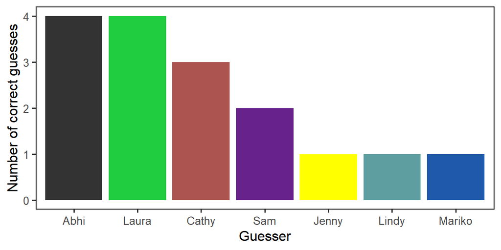

For each player, who guessed their answer correctly?

| Player | Who guessed correctly? |
| --- | --- |
| Abhi | Cathy, Sam |
| Cathy | Abhi |
| Laura | Abhi, Cathy, Mariko, Sam |
| Lindy | Laura |
| Mariko | Cathy, Laura, Lindy |
| Sam | Abhi, Laura |
| Swati | Abhi, Jenny, Laura |

# Q2: In you were a YouTuber, what would your YouTube channel be about?

| Player | Actual answer |
| --- | --- |
| Abhi | Weird linguistic & historical oddities |
| Cathy | Puppies |
| Jenny | Cats being cute jerks |
| Laura | coding in R |
| Lindy | Celebrity gossip |
| Mariko | Cooking |
| Sam | Juggling knives while riding bicycles in Thailand |
| Swati | Cooking and eating |

Who had the most correct answers?

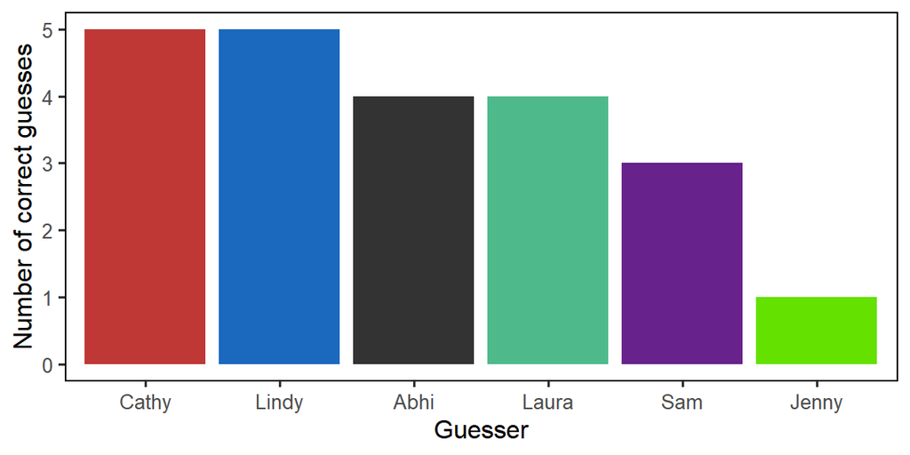

For each player, who guessed their answer correctly?

| Player | Who guessed correctly? |
| --- | --- |
| Abhi | Cathy, Laura, Lindy, Sam |
| Cathy | Abhi, Jenny, Laura |
| Jenny | Cathy, Laura, Lindy |
| Laura | Abhi, Cathy, Lindy, Sam |
| Lindy | Sam |
| Mariko | Cathy, Lindy |
| Sam | Abhi, Cathy, Laura, Lindy |
| Swati | Abhi |

# Q3: Would you rather be a vampire, werewolf, witch, or slayer (like Buffy)?

| Fantasy creature | Players |
| --- | --- |
| Slayer | Abhi, Laura, Mariko |
| Werewolf | Cathy, Sam |
| Witch | Jenny, Lindy, Swati |

Who had the most correct answers?

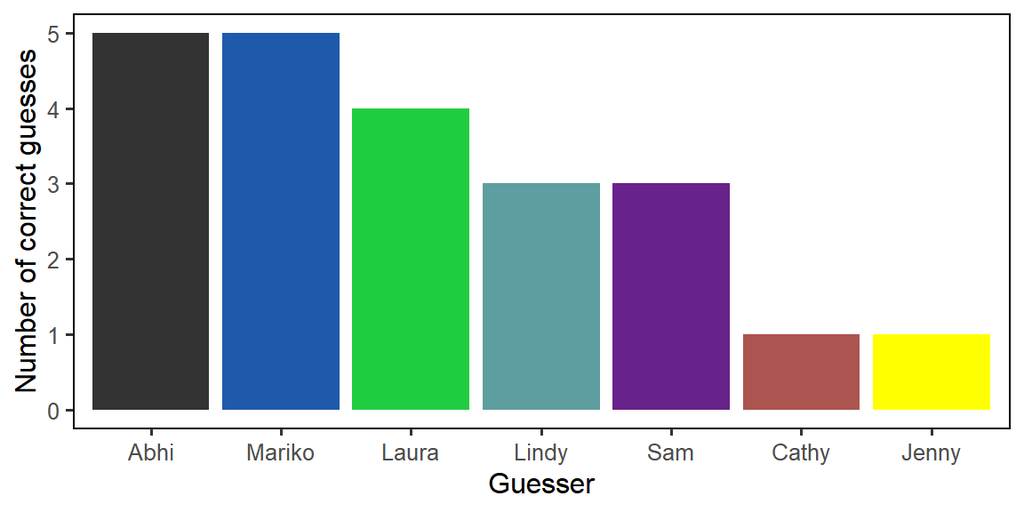

For each player, who guessed their answer correctly?

| Player | Who guessed correctly? |
| --- | --- |
| Abhi | Laura |
| Cathy | Abhi |
| Jenny | Laura, Lindy, Mariko |
| Laura | Lindy, Mariko, Sam |
| Lindy | Abhi, Cathy, Mariko, Sam |
| Mariko | Abhi |
| Sam | Abhi, Jenny, Laura, Lindy, Mariko |
| Swati | Abhi, Laura, Mariko, Sam |

# Q4: Your house is on fire. All living creatures are out but you. What 2 things do you grab on your way to the exit?

| Player | Actual answer |
| --- | --- |
| Abhi | Passport and cellphone |
| Cathy | Heart of Darkness, Passport |
| Jenny | Wallet and phone |
| Laura | a shell necklace my dad gave me, a framed drawing a child made for me |
| Lindy | Phone and lip balm |
| Mariko | Water and black big garbage bags |
| Sam | Backpack and box of special books |
| Swati | Phone, passport |

Who had the most correct answers?

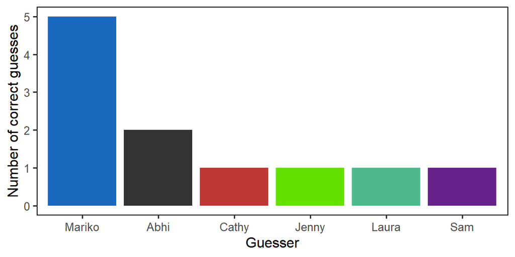

For each player, who guessed their answer correctly?

| Player | Who guessed correctly? |
| --- | --- |
| Abhi | Mariko |
| Cathy | Mariko |
| Laura | Abhi, Jenny, Mariko, Sam |
| Lindy | Abhi, Mariko |
| Sam | Cathy, Laura |
| Swati | Mariko |

# Q5: What is your guilty pleasure song or a song that makes you want to dance/sing along when no one else is watching?

| Player | Actual answer |
| --- | --- |
| Abhi | Penny Lane |
| Cathy | These days, anything will do |
| Jenny | Baby One More Time |
| Laura | “You Spin Me Round (Like a Record)” by Dead or Alive |
| Lindy | Make me feel janelle monae |
| Mariko | September |
| Sam | Wakka wakka by Shakira |
| Swati | Nothing’s Gonna Stop Us Now’ by Starship |

Who had the most correct answers?

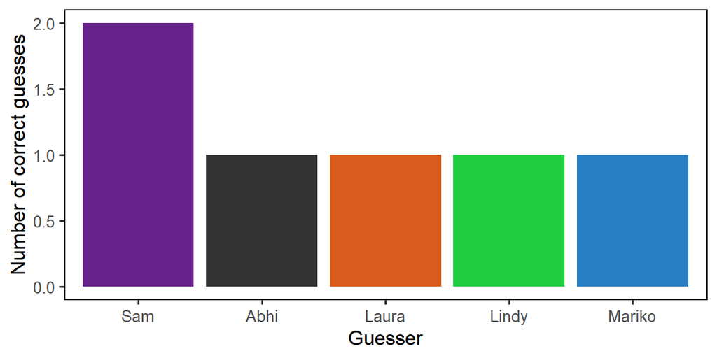

For each player, who guessed their answer correctly?

| Player | Who guessed correctly? |
| --- | --- |
| Abhi | Laura, Sam |
| Cathy | Abhi |
| Jenny | Lindy |
| Laura | Sam |
| Lindy | Mariko |

# Q6: What famous person in history would you like to have dinner with?

| Player | Actual answer |
| --- | --- |
| Abhi | Ada Lovelace |
| Cathy | Leonardo da Vinci |
| Jenny | Henry VIII |
| Laura | Ben Franklin |
| Lindy | Susan Sontag |
| Mariko | Takuya Kimura |
| Sam | Juilia Child. If you don’t know why, I don’t know how to be friends with you |
| Swati | Jawaharlal Nehru |

Who had the most correct answers?

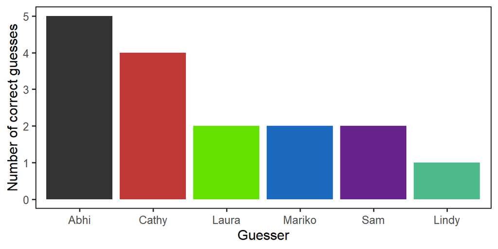

For each player, who guessed their answer correctly?

| Player | Who guessed correctly? |
| --- | --- |
| Jenny | Abhi, Cathy |
| Laura | Abhi, Mariko |
| Lindy | Abhi, Cathy |
| Mariko | Abhi, Cathy, Laura, Lindy, Sam |
| Swati | Abhi, Cathy, Laura, Mariko, Sam |

# Q7: What cartoon character do you most identify with?

| Player | Actual answer |
| --- | --- |
| Abhi | Bugs Bunny |
| Cathy | Wile E Coyote |
| Jenny | Philip J Fry |
| Laura | Suzy from Calvin and Hobbes |
| Lindy | Lisa Simpson |
| Mariko | Tom and Jerry |
| Sam | Taz |
| Swati | Mojo JoJo or Gromit |

Who had the most correct answers?

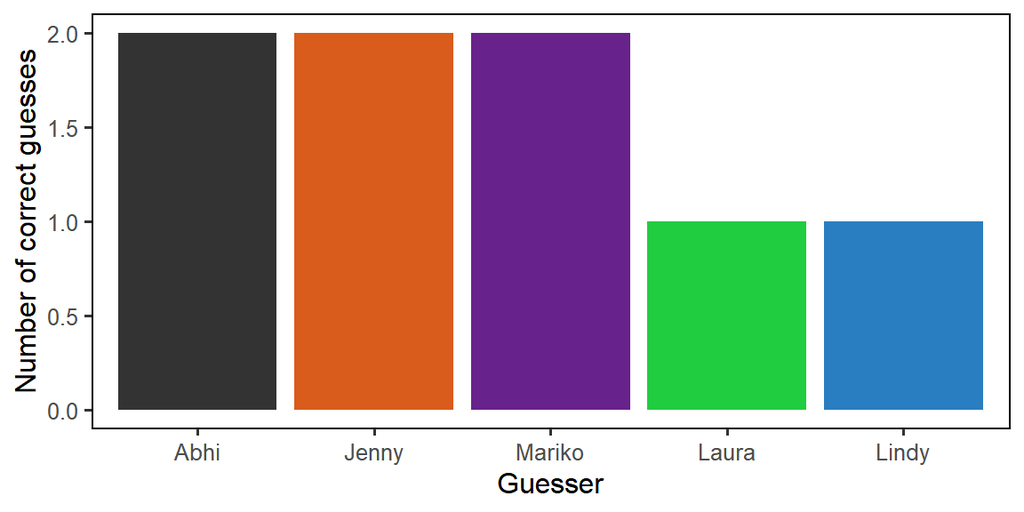

For each player, who guessed their answer correctly?

| Player | Who guessed correctly? |
| --- | --- |
| Abhi | Mariko |
| Cathy | Laura |
| Laura | Jenny, Lindy |
| Mariko | Abhi |
| Swati | Abhi, Jenny, Mariko |

# Q8: What book are you reading right now or wish you were reading right now?

| Player | Actual answer |
| --- | --- |
| Abhi | This is How You Lose the Time War |
| Cathy | Under the Banner of Heaven, Jon Krakauer |
| Jenny | The Last Wish |
| Laura | The Water Dancer by Ta-Nehisi Coates |
| Lindy | The mirror and the light Hilary mantel |
| Mariko | Manga |
| Sam | The Odyssey |
| Swati | Unnatural Causes by PD James |

Who had the most correct answers?

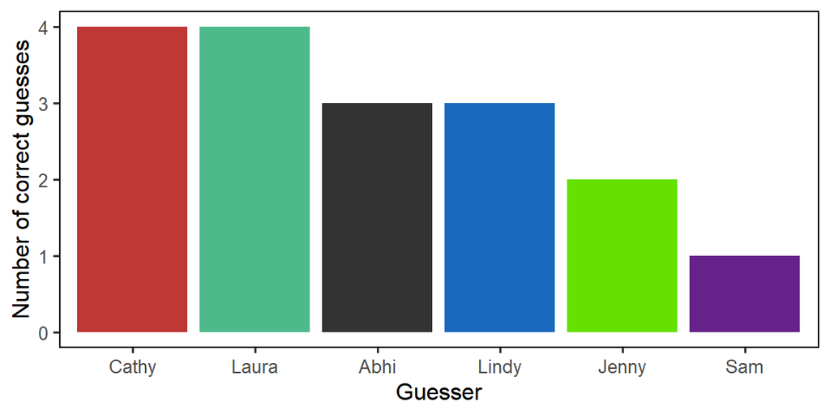

For each player, who guessed their answer correctly?

| Player | Who guessed correctly? |
| --- | --- |
| Abhi | Cathy, Jenny, Laura, Lindy |
| Cathy | Laura |
| Laura | Cathy, Sam |
| Lindy | Cathy |
| Mariko | Abhi, Laura |
| Sam | Abhi, Cathy, Jenny, Laura, Lindy |
| Swati | Abhi, Lindy |

# Overall scores

Number of correct answers:

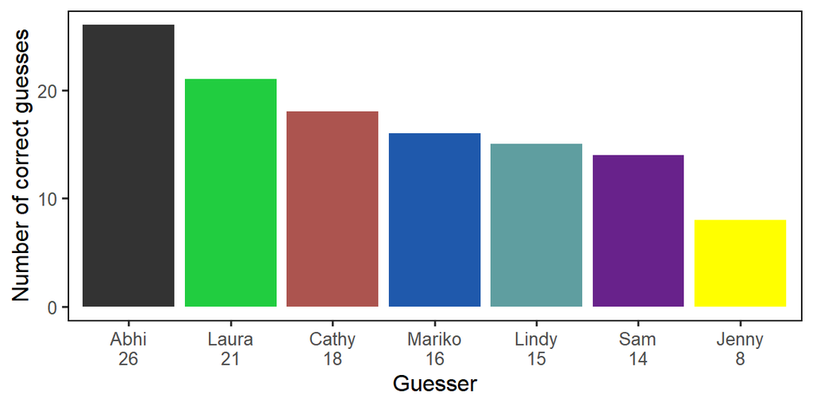

Who knows you best? Who guessed your answers correctly the most?

| Player | Known best by | Number of correct guesses |
| --- | --- | --- |
| Abhi | Laura | 4 |
| Cathy | Abhi | 4 |
| Jenny | Lindy | 3 |
| Laura | Sam | 6 |
| Lindy | Abhi & Cathy & Mariko | 3 |
| Mariko | Abhi | 4 |
| Sam | Laura | 5 |
| Swati | Abhi | 6 |